# HW05

Jiuru Lyu

2022-10-25

# Importing Packages

```r
library(tidyverse)
library(babynames)
```

# Question 1

*For the data set “babynames,” calculate the percent of female children each year in the following steps, then plot the percent over time. (pipe all steps together)*

1. calculate the total number of children by sex each year;
2. reshape the above data set;
3. create a new variable percent;
4. plot the percent over time (year);

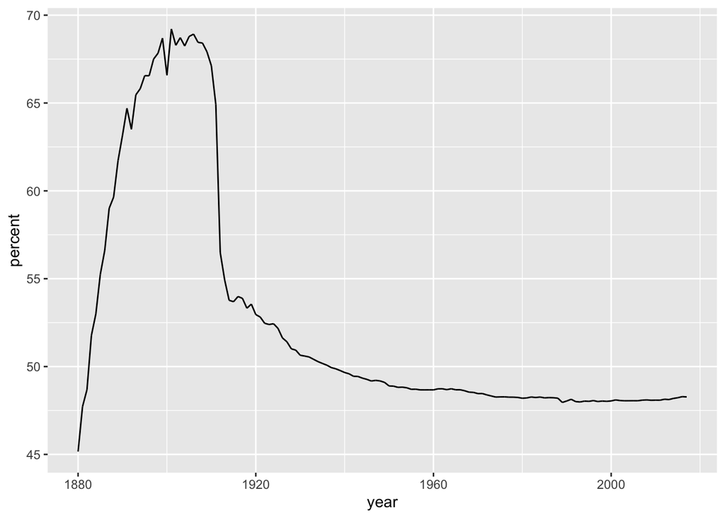

```r
babynames %>%
  group_by(year) %>%
  mutate(total = sum(n)) %>%
  filter(sex == "F") %>%
  select(year, n, total) %>%
  mutate(female = sum(n)) %>%
  summarize(percent = female / total * 100) %>%
  ggplot(aes(x = year, y = percent)) + geom_line()
```

# Question 2

*Explore the data set “who” in the tidyverse package in the following steps. This data set is about the World Health Organization Global Tuberculosis Report, and accompanying global populations. (pipe all steps together)*

Run this following code first:

```r
names(who) <- stringr::str_replace(names(who), "newrel", "new_rel")
```

1. Put together all the columns from new_sp_m014 to new_rel_f65, and give your variables names “codes” and “n”, then select just the “country”, “year”, “codes” and “n” variables.
2. Separate the “codes” variable into “new”, “type”, “sexage”.
3. Then separate the “sexage” into “sex” and “age”.
4. For country, year, and sex compute the total number of cases of TB.
5. Choose three countries of your interest and plot the trend of the number of cases by sex over time.

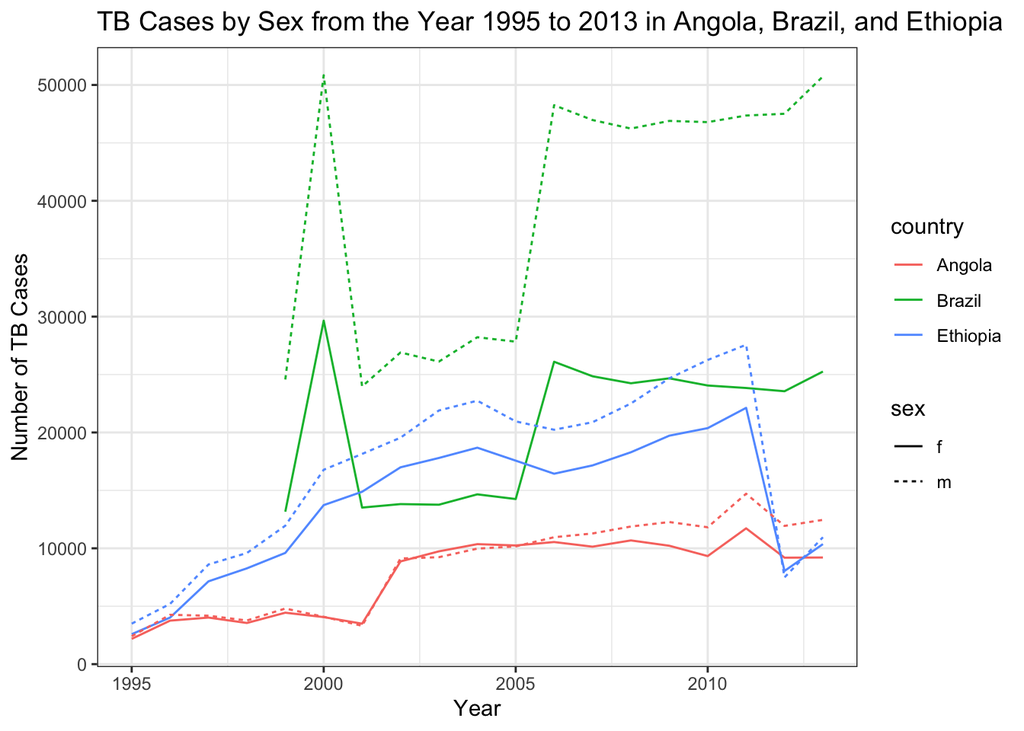

```r
who %>%
  pivot_longer(c("new_sp_m014":"new_rel_f65"), names_to = "codes", values_to = "n") %>%
  select(country, year, codes, n) %>%
  na.omit() %>%
  separate("codes", into = c("new", "type", "sexage"), sep = "_") %>%
  separate("sexage", into = c("sex", "age"), sep = 1) %>%
  group_by(country, year, sex)  %>%
  summarize(total = sum(n)) %>%
  filter(country == "Angola" | country == "Ethiopia" | country == "Brazil") %>%
  ggplot(aes(x = year, y = total, color = country)) +
    geom_line(aes(linetype = sex)) +
    labs(
      title = "TB Cases by Sex from the Year 1995 to 2013 in Angola, Brazil, and Ethiopia",
      x = "Year",
      y = "Number of TB Cases"
    ) +
    theme_bw()
```